# DATA 607 - Final Project

Paul Britton

# Project Overview

For this project, I’m attempting to classify documents from the Library of Congress’s [Chronicling America](https://chroniclingamerica.loc.gov/) initiative as either containing specific financial data, or not. I have several goals for this project:

1. Classify pages (and thus newpapers) according to whether or not they contain specific financial content
2. Familiarize myself with this data set with a goal to facilitate future work. There is A LOT of interesting stuff that could be done here
3. Improve my text-mining skills

All of work assodicated with this project can be found in my [github](https://github.com/plb2018/DATA607/tree/master/DATA_607_FinalProject) including some sample data. The output itself can be found on [rpubs](http://rpubs.com/plb_lttfer/388909) Given the size and location of the data set that I used, I have decided to provide tools that allow any user to collect them from the source themselves. The Library of Congress seems committed to maintaining availability of data so I don’t have any concerns here regarding reproducibility.

## About the Data

Chronicling America currently has about 13.3M pages archived and seems to be continually expanding their data set. The data is available in a few formats:

- [Images](https://chroniclingamerica.loc.gov/lccn/sn83025287/1883-12-29/ed-1/seq-7/). They can also be downloaded as hi-res .jp2 files.
- [Text](https://chroniclingamerica.loc.gov/lccn/sn83025287/1883-12-29/ed-1/seq-7/ocr/). This was created using [OCR](https://chroniclingamerica.loc.gov/ocr/) and thus is far from perfect, especially for older or messier newspapers.
- [XML](https://github.com/plb2018/DATA607/raw/master/DATA_607_FinalProject/ocr.xml). The XML appears to be an enriched version of the OCR which contains word coordinates within the page, OCR confidence scores. Probably beyond the scope of this project, but something that I hope to work with in the future to automate the extraction of data.

A few examples of the kind of data that we’re looking for here; both images and corresponding OCR data.

Daily price quotes for various futures markets:

### Example 1

#### Image

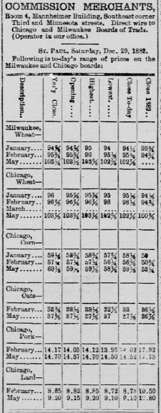

Daily Futures Quotes - Circa Dec 29, 1883

#### OCR:

```
COMMISSION MERCHANTS,
Boom 4, Mann helper Building, Southeast comer
Third and Minnesota street?. Direct wire to
Chicago and Milwaukee Boards of Trad*.
(Operator is our office.)
Bt. Paul, Friday, Dec. 23, 1833.
Following is to-day's rango of prices on the
Milwaukee and Chicago boards:
???""">" ! I I I ' fit
1 w a I- s S s
I a ? ? f 111
: ? : . : c 3 :
Milwaukee, j
Wheat- "
January.... 95 i 94% S5Ji Si% 94%' 92%
February... 96% 95& Oo^'i 95% S5& 98%
May 1C3% 103% 103% 108% ....
Chicago,
Wheat-
January.... S6>i 95%' 96% Sssi 36 92%
February.. 97% 98% 91% S6s£ 96% 93 %
March ;
May 1G4% 1C8& 10*34 1«3% ICS^ »5f
```

### Example 2

#### Image

Hourly Price quotes for various futures market:

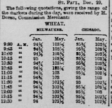

Hourly Futures Quotes - Circa Dec 29, 1883

#### OCR

```
The following quotations, glrti tt the r>n^« of
the 2&rkets durissthe day, wars nesi - by XL.
Doran, Co2tj»ion Merchant:
. WHEAT.
Jan. May. Jaa. Kay.
9-10 A.M. 84% 10SH SSK- 103Ji
9^5 - t4si lOS-^. 9JJi 108H
10:00 " 95 103 V toft lUSK
10a5 " 85 IC3S B*£ 104 V
10*0 M 95 X 108% 96 IMU
LQAi " 85# 113 % 91)? 104 %
11*0 ??? 95 10J% H¥ 10: V
11:15 " . 95 l«»i 9»« 104
11*) " 95 10»»i »5% 10SK
HHa " .84% 108* 95% 199%
13.-0O " 95 108% 86 104
12:15 " »5 ~?????? 103% 96^ 104^
11:10 M t*% 1C3% 96% K-4 j
1345 " 84« 103%- C-6 10S5<
IsOQ " 84% ' l'J3% 86 ltSXj
```

As can be seen from the above, the quality of the OCR leaves something to be desired. My hope here is that, despite the translation being either incorrect or totally illegible to humans, there are still enough similarities between financial pages for them to be grouped together and that they are distinct from non-financial pages.

```r
rm(list = ls())
```

```r
library(jsonlite)
library(data.tree)
library(stringr)
library(dplyr)
library(tidyr)
library(lubridate)
library(tm)
library(qdap)
library(ggplot2)
library(httr)
library(RTextTools)
library(knitr)
```

## Collect the Data Dictionary

Chronicling America provides a well organized data dictionary and bulk-downloading facility. The first thing that we’ll do is get a list of files to download.

```r
url <- "http://chroniclingamerica.loc.gov/ocr.json"
ocr <- fromJSON(url)
ocr <- data.frame(ocr['ocr'])

kable(head(select(ocr,ocr.url,ocr.size),5))
```

| ocr.url | ocr.size |
| --- | --- |
| http://chroniclingamerica.loc.gov/data/word_coordinates/ocr/batch_whi_lucretia_ver01.tar.bz2 | 1314552281 |
| http://chroniclingamerica.loc.gov/data/word_coordinates/ocr/batch_whi_inez_ver01.tar.bz2 | 1524682389 |
| http://chroniclingamerica.loc.gov/data/word_coordinates/ocr/batch_wvu_jim_ver01.tar.bz2 | 1024492998 |
| http://chroniclingamerica.loc.gov/data/word_coordinates/ocr/batch_wvu_iconia_ver01.tar.bz2 | 975727516 |
| http://chroniclingamerica.loc.gov/data/word_coordinates/ocr/batch_wvu_horta_ver01.tar.bz2 | 990614566 |

## Download the Data

The list above looks usable so now we can proceed to downloading some data. Note that some of these files are pretty large (1GB compressed) so I’ve included a “test” mode in my download function that grabs the 5 smallest files. Data is downloaded to CWD unless otherwise specified

```r
getArchives <- function(ocr.df,outPath = NULL, testMode = TRUE){
  if(testMode){ocr.df<- head(ocr.df[order(ocr.df$ocr.size),],5)}

  for (row in 1:nrow(ocr.df)){
    data.url <- as.character(ocr.df[row,"ocr.url"])
    print(paste("Downloading: ",data.url),sep=" ")
    download.file(data.url,
      destfile=paste(outPath,
      tail(unlist(strsplit(data.url,"\\/")),1)))
    }
}


#if testMode = True, the function only downloads the smallest file
getArchives(ocr,testMode=TRUE)

#if testMode = False the function download everything.  Takes forever!
#getArchives(ocr,testMode=FALSE)
```

## Uncompressing

Once the data is downloaded, it will need to be manually unzipped from .bz2 format. While R seems to have good support for bz2, I couldn’t seem to get it to work seamlessly with .tar.bz2 files containing a large tree-structure within.

After we have unzipped, we can untar the rest as below. Note that given some of the file sizes, this can take a while to run, so I’ve included a sample unzip from github. Note that these files contain both .txt and .xml, but no images.

```r
#I saved some small sample files on my github for demonstration purposes
untar("https://github.com/plb2018/DATA607/blob/master/DATA_607_FinalProject/sampleData/batch_in_alford_ver01.tar",
      compressed = "bzip2",
      exdir = "test")


#A local file that i was working with
#untar("batch_mnhi_anoka_ver02.tar",
#      compressed = "bzip2",
#      exdir = "test")
```

## Inspect

Let’s take a look at the file structure contained within the compressed files.

```r
path <- list.dirs("test/paper_name")

files.tree <- data.tree::as.Node(data.frame(pathString = path))

files.tree
```

```
##                      levelName
## 1 test
## 2  °--paper_name
## 3      °--year
## 4          °--month
## 5              °--day_of_month
## 6                  °--edition
## 7                      °--page
```

We see that basically, ever paper,year, month, day, edition and page gets its own folder. This means that we have to crawl these paths to get to all the actual files. I’m tempted to sidestep this file structure by saving all the files in a single directory and encoding the files names with the same info as provided by the dir tree… but we won’t do that right now.

## Get the Files

We’ll get a list of all the files within the tree structure

```r
ocr.names <- list.files("test/cat/sn83025287",
           full.names = T,
           recursive = T)

ocr.names <- as.data.frame(ocr.names,
                           stringsAsFactors = FALSE)


kable(head(ocr.names,6))
```

| ocr.names |
| --- |
| test/cat/sn83025287/1883/01/01/ed-1/seq-1/ocr.txt |
| test/cat/sn83025287/1883/01/01/ed-1/seq-1/ocr.xml |
| test/cat/sn83025287/1883/01/01/ed-1/seq-2/ocr.txt |
| test/cat/sn83025287/1883/01/01/ed-1/seq-2/ocr.xml |
| test/cat/sn83025287/1883/01/01/ed-1/seq-3/ocr.txt |
| test/cat/sn83025287/1883/01/01/ed-1/seq-3/ocr.xml |

## Transform

Now we’ll transform the data. Essentially, I’m going to chop up the file-paths and put all that data into a df to be used as meta-data in my corpus further along. We’ll concatenate the year, month and day into a proper date, add a column that contains the day of the week (potentially useful in finance) and a column to flag whether the document contains financial data or not.

It’s also a logical place to separate the .txt and .xml files at this point.

```r
new.cols <- c("rootfolder","cat","id","YYYY","mm","dd","edition","pageNum","fname")


ocr.names %>%
  filter(str_detect(ocr.names,".txt")) %>%
  separate(ocr.names,
           ocr.names,
           into=new.cols,
           sep="/",
           remove=F,
           convert=F,
           extra="warn",
           fill="warn")-> ocr.txt

ocr.names %>%
  filter(str_detect(ocr.names,".xml")) %>%
  separate(ocr.names,
           ocr.names,
           into=new.cols,
           sep="/",
           remove=F,
           convert=F,
           extra="warn",
           fill="warn")-> ocr.xml



ocr.txt$edition <- gsub("ed-","",ocr.txt$edition)
ocr.txt$pageNum <- gsub("seq-","",ocr.txt$pageNum)
ocr.txt$date <- with(ocr.txt, ymd(sprintf('%04s%02s%02s', YYYY, mm, dd)))
ocr.txt$wDay <- wday(ocr.txt$date,label=T)
ocr.txt$hasData <- "0"
ocr.txt$text <- ""
colnames(ocr.txt)[1] <- "doc_id"

kable(head(ocr.txt,5))
```

| doc_id | rootfolder | cat | id | YYYY | mm | dd | edition | pageNum | fname | date | wDay | hasData | text |
| --- | --- | --- | --- | --- | --- | --- | --- | --- | --- | --- | --- | --- | --- |
| test/cat/sn83025287/1883/01/01/ed-1/seq-1/ocr.txt | test | cat | sn83025287 | 1883 | 01 | 01 | 1 | 1 | ocr.txt | 1883-01-01 | Mon | 0 |  |
| test/cat/sn83025287/1883/01/01/ed-1/seq-2/ocr.txt | test | cat | sn83025287 | 1883 | 01 | 01 | 1 | 2 | ocr.txt | 1883-01-01 | Mon | 0 |  |
| test/cat/sn83025287/1883/01/01/ed-1/seq-3/ocr.txt | test | cat | sn83025287 | 1883 | 01 | 01 | 1 | 3 | ocr.txt | 1883-01-01 | Mon | 0 |  |
| test/cat/sn83025287/1883/01/01/ed-1/seq-4/ocr.txt | test | cat | sn83025287 | 1883 | 01 | 01 | 1 | 4 | ocr.txt | 1883-01-01 | Mon | 0 |  |
| test/cat/sn83025287/1883/01/01/ed-1/seq-5/ocr.txt | test | cat | sn83025287 | 1883 | 01 | 01 | 1 | 5 | ocr.txt | 1883-01-01 | Mon | 0 |  |

## Build a Corpus

Next we’ll take the dataframe that we’ve just created and add the actual text content from the files. Once again, this can take a while.

```r
ocr.txt$text <- sapply(ocr.txt$doc_id, readChar,nchars=99999999)
ocr.corpus <- Corpus(DataframeSource(ocr.txt))

#we'll add the doc_id as meta just in case we need it for some reason...
meta(ocr.corpus,tag="doc_id") <-ocr.txt$doc_id

kable(head(meta(ocr.corpus),5))
```

| rootfolder | cat | id | YYYY | mm | dd | edition | pageNum | fname | date | wDay | hasData | doc_id |
| --- | --- | --- | --- | --- | --- | --- | --- | --- | --- | --- | --- | --- |
| test | cat | sn83025287 | 1883 | 01 | 01 | 1 | 1 | ocr.txt | 1883-01-01 | Mon | 0 | test/cat/sn83025287/1883/01/01/ed-1/seq-1/ocr.txt |
| test | cat | sn83025287 | 1883 | 01 | 01 | 1 | 2 | ocr.txt | 1883-01-01 | Mon | 0 | test/cat/sn83025287/1883/01/01/ed-1/seq-2/ocr.txt |
| test | cat | sn83025287 | 1883 | 01 | 01 | 1 | 3 | ocr.txt | 1883-01-01 | Mon | 0 | test/cat/sn83025287/1883/01/01/ed-1/seq-3/ocr.txt |
| test | cat | sn83025287 | 1883 | 01 | 01 | 1 | 4 | ocr.txt | 1883-01-01 | Mon | 0 | test/cat/sn83025287/1883/01/01/ed-1/seq-4/ocr.txt |
| test | cat | sn83025287 | 1883 | 01 | 01 | 1 | 5 | ocr.txt | 1883-01-01 | Mon | 0 | test/cat/sn83025287/1883/01/01/ed-1/seq-5/ocr.txt |

## Bag O’ Words… (or something like it)

Now we’re going to employ a “bag of words” like method to pare down the data for manual classification.

One of the problems that I face is that I need a sample of classified documents in order to train the SVM process that I’m planning on applying here. My idea is to short-list the docs using a bag-of-words approach and then manually classify.

Cursory inspection tells me that certain words are more common within target pages than non-target pages. What I do here is remove everything but those relevant words and work with that (significantly reduced) output. This speeds things up a lot.

```r
keepWords<-content_transformer(function(x,words) {
    regmatches(x,
        gregexpr(paste0("\\b(",  paste(words,collapse="|"),"\\b)"), x)
    , invert=T)<-" "
    x
})

keep<-c("oats","corn","bushel","wheat","rye","barley")


bagOwords.corpus <- ocr.corpus %>%
  tm_map(content_transformer(tolower)) %>%
  tm_map(removePunctuation) %>%
  tm_map(removeNumbers) %>%
  tm_map(removeWords,words=stopwords("english")) %>%
  tm_map(stripWhitespace) %>%
  tm_map(stemDocument,language = "english") %>%
  tm_map(keepWords,keep)


ocr.dtm <- DocumentTermMatrix(bagOwords.corpus)
```

```r
t <- as.data.frame(as.matrix(ocr.dtm),stringsAsFactors = F)
t$sum <- rowSums(t)

target <- meta(ocr.corpus[which(t$sum >70)],tag="doc_id")

kable(head(target,5))
```

|  | doc_id |
| --- | --- |
| 55 | test/cat/sn83025287/1883/01/06/ed-1/seq-7/ocr.txt |
| 79 | test/cat/sn83025287/1883/01/09/ed-1/seq-7/ocr.txt |
| 87 | test/cat/sn83025287/1883/01/10/ed-1/seq-7/ocr.txt |
| 94 | test/cat/sn83025287/1883/01/11/ed-1/seq-6/ocr.txt |
| 110 | test/cat/sn83025287/1883/01/13/ed-1/seq-6/ocr.txt |

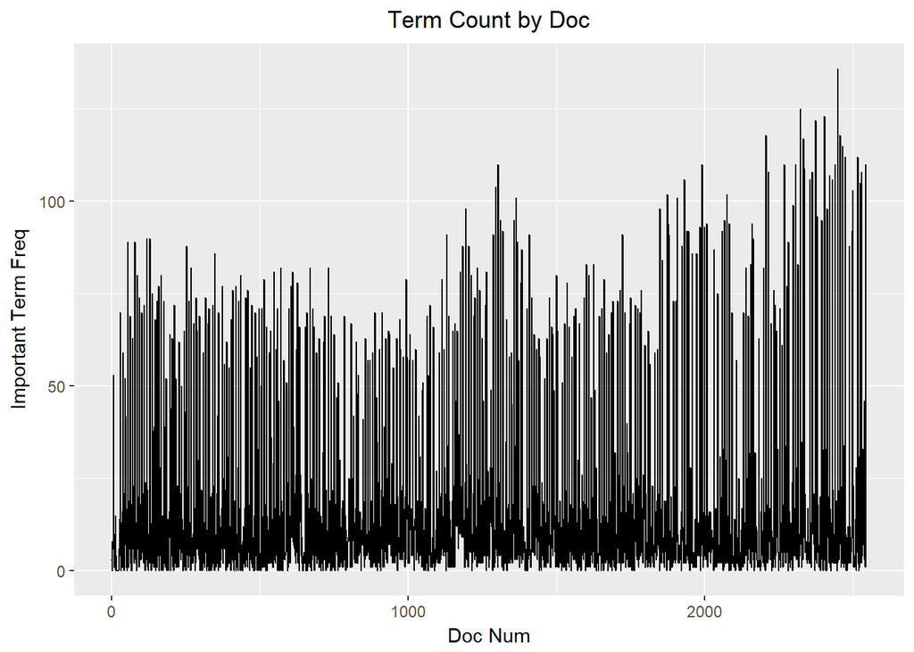

```r
ggplot(t,aes(x=seq(1, nrow(t), by=1),y=t$sum)) +
  geom_line() +
  ylab("Important Term Freq") +
  xlab("Doc Num") +
  ggtitle("Term Count by Doc")+
  theme(plot.title = element_text(hjust = 0.5))
```

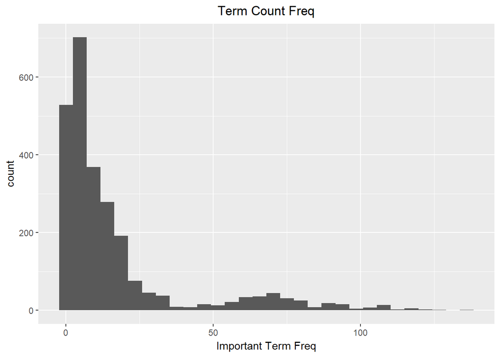

```r
qplot(t$sum, geom="histogram") +
  xlab("Important Term Freq") +
  ggtitle("Term Count Freq")+
  theme(plot.title = element_text(hjust = 0.5))
```

We can see that most of the documents contain <25 occurrences of the “keep” words but that there is a bit of a jump around the 75-count mark. To be clear, my intention with this “bag of words” approach is to identify documents that have a higher probability of containing financial data for manual classification, but I’m not overly concerned with being wrong.

#Get Images

So we’ve identified a handful of files that contain relevant words. Next we’re going to download images (.pdfs) so that we can manually inspect and classify them. Once again, even the .pdfs are about 5mb each, so this takes a while.

We basically parse the file names to reconstruct the image URL at Chronicling America.

```r
#the base URL
image.base <- "https://chroniclingamerica.loc.gov/lccn/"

for (i in unlist(target)){

  str <- unlist(strsplit(i,split='/'))
  dt <- paste(str[[3]],str[[4]],str[[5]],sep="-")
  fname <- paste(str[7],".pdf",sep="")
  img.url <- paste(str[2],dt,str[6],fname,sep="/")


  #print(paste(image.base,img.url,sep=""))

  #i've commented this out so i don't accidentally end up downloading tons of images
  #GET(paste(image.base,img.url,sep=""),
  # write_disk(paste("test/images/",gsub("/","_",img.url),sep=""),overwrite=F))

}
```

# Add Classifiaction Info

For the manual classification, rather than classifying every document as either “TRUE” or “FALSE”, I’ve created a list that contains documents for which my condition is “TRUE”. On a date-by-date basis, this is valid as newspapers (particularly of this vintage) generally have futures quotes confined to one single page per date.

We go through my manually classified items; a simple text file containing paper id, date and page num. We identify the index for each id+date+pageNum combo in the corpus, and then change that flag from from FALSE to TRUE.

```r
flags <- read.csv("https://raw.githubusercontent.com/plb2018/DATA607/master/DATA_607_FinalProject/market_data.txt",header = T, stringsAsFactors = F)

#create a list to store our updated info
hasData <- rep(FALSE,nrow(meta(ocr.corpus)))

for (f in 1:nrow(flags)){

  id <- ymd(flags[f,1])
  dt <- flags[f,2]
  pg <- flags[f,3]

  #print(paste(id,dt,pg))

  idx_id <- (meta(ocr.corpus,tag = "id") == "sn83025287")
  idx_dt <- (meta(ocr.corpus,tag = "date") == dt)
  idx_pg <- (meta(ocr.corpus,tag = "pageNum") == pg)

  #idx <- data.frame(id=idx_id,dt=idx_dt,pg=idx_pg)
  idx <- data.frame(dt=idx_dt,pg=idx_pg)

  idx <- rowSums(idx) == 2

  #meta(ocr.corpus[idx],tag="hasData") <-1

  hasData[idx] <- TRUE


}

#update our corpus classification
meta(ocr.corpus,tag="hasData") <-hasData

kable(head(meta(ocr.corpus,tag="hasData"),5))
```

| hasData |
| --- |
| FALSE |
| FALSE |
| FALSE |
| FALSE |
| FALSE |

# Build a Model

Now that we have some classified data, we can build a model. Recall that previously we’d used a stripped down version of the corpus. Here, we’re going to revert back to the original, full corpus.

We’ll start by cleaning the original corpus. Then we’ll build a container for the SVM.

```r
ocr.corpus <- ocr.corpus %>%
  tm_map(content_transformer(tolower)) %>%
  tm_map(removePunctuation) %>%
  tm_map(removeNumbers) %>%
  tm_map(removeWords,words=stopwords("english")) %>%
  tm_map(stripWhitespace) %>%
  tm_map(stemDocument,language = "english")


#down sample for testing
data <- sample(ocr.corpus,2500)
ocr.dtm <- DocumentTermMatrix(data)

#setup for building our container
labels <- unlist(meta(data, "hasData")[,1])
N <- length(unlist(meta(data, "hasData")[,1]))
pct <-0.80
r<-round(N*pct,0)



container <- create_container(
  ocr.dtm,
  labels = labels,
  trainSize = 1:r,
  testSize = (r+1):N,
  virgin=FALSE)
```

## Train the Model

Next we’ll train the actual model on some data. I’ve chosen SVM as it appears to be a reasonable approach for problems with high dimensionality, which this is.

```r
svm.model <- train_model(container, "SVM")
svm.out <- classify_model(container, svm.model)
```

## Inspect the Model

Now we examine the results of the model. Below we see a table with all of the predicted values alongside the real TRUE values. I think it’s a good way to show the data as the real TRUE observations are few relative to the whole sample.

```r
true.labels <- labels[(r+1):N]
predicted.labels <- svm.out[,"SVM_LABEL"]
svm.out$real <- true.labels

kable(head(svm.out[svm.out$real == TRUE,],20))
```

|  | SVM_LABEL | SVM_PROB | real |
| --- | --- | --- | --- |
| 11 | FALSE | 0.5709651 | TRUE |
| 27 | TRUE | 0.9740367 | TRUE |
| 42 | TRUE | 0.5881983 | TRUE |
| 80 | TRUE | 0.9266203 | TRUE |
| 146 | TRUE | 0.7238994 | TRUE |
| 148 | TRUE | 0.7015101 | TRUE |
| 151 | TRUE | 0.8944307 | TRUE |
| 157 | TRUE | 0.9719772 | TRUE |
| 158 | TRUE | 0.9558798 | TRUE |
| 175 | TRUE | 0.9724161 | TRUE |
| 209 | TRUE | 0.7680566 | TRUE |
| 233 | TRUE | 0.9155681 | TRUE |
| 238 | TRUE | 0.9041032 | TRUE |
| 248 | FALSE | 0.5607846 | TRUE |
| 250 | TRUE | 0.9746006 | TRUE |
| 286 | TRUE | 0.9820918 | TRUE |
| 306 | TRUE | 0.8618724 | TRUE |
| 323 | TRUE | 0.8272815 | TRUE |
| 365 | FALSE | 0.5568750 | TRUE |
| 371 | TRUE | 0.9228798 | TRUE |

```r
recall_accuracy(true.labels,predicted.labels)
```

```
## [1] 0.982
```

```r
length(which(predicted.labels == TRUE & true.labels == TRUE)) / length(which(true.labels ))
```

```
## [1] 0.88
```

So the model appears to be able to do a reasonable job of classifying which documents meet my criteria and which do not. I find this impressive given that the training set is relatively small and that the documents are so messy.

## Outsample Attempt

Finally, we’ll try to apply the model that we’ve just trained on some outsample data and take a quick look at the results.

We’ll start by loading up some uncategorized data and formatting it.

```r
#load uncategorized data
uncat.names <- list.files("test/uncat/sn83025287",
           full.names = T,
           recursive = T)

uncat.names <- as.data.frame(uncat.names,
                           stringsAsFactors = FALSE)



uncat.names %>%
  filter(str_detect(uncat.names,".txt")) %>%
  separate(uncat.names,
           uncat.names,
           into=new.cols,
           sep="/",
           remove=F,
           convert=F,
           extra="warn",
           fill="warn")-> uncat.txt

uncat.txt$edition <- gsub("ed-","",uncat.txt$edition)
uncat.txt$pageNum <- gsub("seq-","",uncat.txt$pageNum)
uncat.txt$date <- with(uncat.txt, ymd(sprintf('%04s%02s%02s', YYYY, mm, dd)))
uncat.txt$wDay <- wday(uncat.txt$date,label=T)
uncat.txt$hasData <- FALSE
uncat.txt$text <- ""
colnames(uncat.txt)[1] <- "doc_id"


uncat.txt <- tail(uncat.txt,50)

uncat.txt$text <- sapply(uncat.txt$doc_id, readChar,nchars=99999999)
uncat.corpus <- Corpus(DataframeSource(uncat.txt))
```

We’ll then create a dtm. Note that a slightly different method is required here as model appears to be picky about inputs. As such, I had to give it some info about the matrix originally used to train the model.

```r
uncat.labels <- unlist(meta(uncat.corpus, "hasData")[,1])

#IMPORTANT NOTE:  the create_matrix function seems to throw an error only when knitting.
#This is an ugly (but effective) fix.  When running, an edit window will pop-up.
#Change "Acronym" to "acronym" in line ~42 and it work.  Obscure, yet effective.

trace("create_matrix", edit=T)
```

```
## Tracing function "create_matrix" in package "RTextTools"
```

```
## [1] "create_matrix"
```

```r
dtm <- create_matrix(uncat.txt,
                     originalMatrix=ocr.dtm,
                     toLower = TRUE,
                     removePunctuation = TRUE,
                     removeNumbers=TRUE,
                     removeStopwords = TRUE ,
                     stemWords  = TRUE)
```

We then create the container and run the model

```r
uncat.container <- create_container(
  dtm,
  labels = labels,
  testSize = 1:50,
  virgin=FALSE)


uncat.out <- classify_model(uncat.container,svm.model)

kable(head(uncat.out,10))
```

| SVM_LABEL | SVM_PROB |
| --- | --- |
| FALSE | 0.9997626 |
| FALSE | 0.9999277 |
| FALSE | 0.9997707 |
| FALSE | 0.9997551 |
| FALSE | 0.9997543 |
| FALSE | 0.9997582 |
| FALSE | 0.9997544 |
| FALSE | 0.9997756 |
| FALSE | 0.9998396 |
| FALSE | 0.9997760 |

```r
uncat.out[uncat.out$SVM_LABEL == TRUE,]
```

```
## [1] SVM_LABEL SVM_PROB
## <0 rows> (or 0-length row.names)
```

We see that according to the model, none of the 50 out-sample pages appear to have any data of interest. A cursory investigation of the associated image files suggests that this is reasonably, although not perfectly accurate. Either way, my suspicion is that the model needs a larger training set, and I intend to continue working on that.

# Summary

In this project, I was able to

1. Acquire and unpack the desired data
2. Manipulate and transform the data
3. Significantly reduce manual efforts using “bag of words”, including automated download of image files for manual inspection
4. Manually classify, then automatically tag the data
5. Build an SVM model, which was surprisingly accurate based on the input / intuition
6. Run the model on totally “out of sample” data.

# Future Work

I intend to continue to explore this model and the data set in general. Once I have located a significant number of pages which contain the content that I am interested in, I plan to take a crack at automatic extraction of that data.